# turtle_commands_B

## turtle_commands_B

#### Question

1. Consider the $L$-system (and angle) defined below:
   - Start: `A`
   - Rules:  
     `A > B++A++A++B`  
     `B > AB[A-CC-CC-CCA]BA`  
     `C > CC`
   - Number of recursions (number of iterations):
     - 5
   - Angle
     - 90°

   When we use the resulting string (and angle) to drive turtle graphics, using https://draemm.li/various/fractals/l-systems/, what image is produced?

   You can also use [this L-system string generator](https://chadworley.github.io/Lsys_string_gen.html) along with [Turbo Turtle](https://scratch.mit.edu/projects/1225522722/editor/) to generate the pattern.

   (You will need to adjust other parameters to get image rotated, centered, and scaled.)

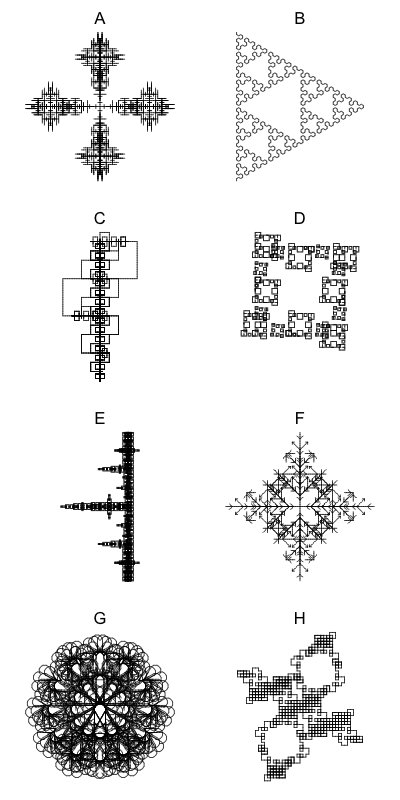

   1. A
   2. B
   3. C
   4. D
   5. E
   6. F
   7. G
   8. H

#### Question

2. Consider the $L$-system (and angle) defined below:
   - Start: `A+++A+++A+++A`
   - Rules:  
     `A > B--B`  
     `B > AA+++AA`
   - Number of recursions (number of iterations):
     - 7
   - Angle
     - 30°

   When we use the resulting string (and angle) to drive turtle graphics, using https://draemm.li/various/fractals/l-systems/, what image is produced?

   You can also use [this L-system string generator](https://chadworley.github.io/Lsys_string_gen.html) along with [Turbo Turtle](https://scratch.mit.edu/projects/1225522722/editor/) to generate the pattern.

   (You will need to adjust other parameters to get image rotated, centered, and scaled.)

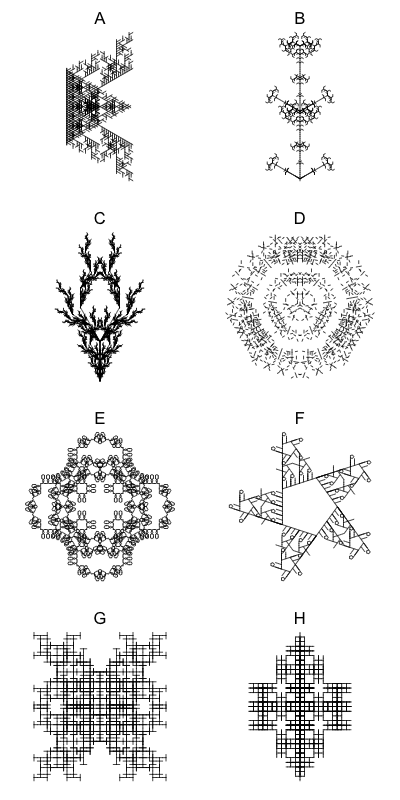

   1. A
   2. B
   3. C
   4. D
   5. E
   6. F
   7. G
   8. H

#### Question

3. Consider the $L$-system (and angle) defined below:
   - Start: `[A]+[A]+[A]+[A]+[A]+[A]`
   - Rules:  
     `A > AA[-B][+B]B`  
     `B > [-ABC][+ABC]`  
     `C > A[-CB][+CB]`
   - Number of recursions (number of iterations):
     - 4
   - Angle
     - 60°

   When we use the resulting string (and angle) to drive turtle graphics, using https://draemm.li/various/fractals/l-systems/, what image is produced?

   You can also use [this L-system string generator](https://chadworley.github.io/Lsys_string_gen.html) along with [Turbo Turtle](https://scratch.mit.edu/projects/1225522722/editor/) to generate the pattern.

   (You will need to adjust other parameters to get image rotated, centered, and scaled.)

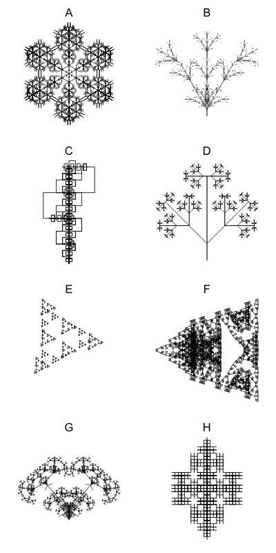

   1. A
   2. B
   3. C
   4. D
   5. E
   6. F
   7. G
   8. H

#### Question

4. Consider the $L$-system (and angle) defined below:
   - Start: `A`
   - Rules:  
     `A > [---B][-B][+B][+++B]`  
     `B > BD[++DA][--DA]B`  
     `D > DD`
   - Number of recursions (number of iterations):
     - 5
   - Angle
     - 45°

   When we use the resulting string (and angle) to drive turtle graphics, using https://draemm.li/various/fractals/l-systems/, what image is produced?

   You can also use [this L-system string generator](https://chadworley.github.io/Lsys_string_gen.html) along with [Turbo Turtle](https://scratch.mit.edu/projects/1225522722/editor/) to generate the pattern.

   (You will need to adjust other parameters to get image rotated, centered, and scaled.)

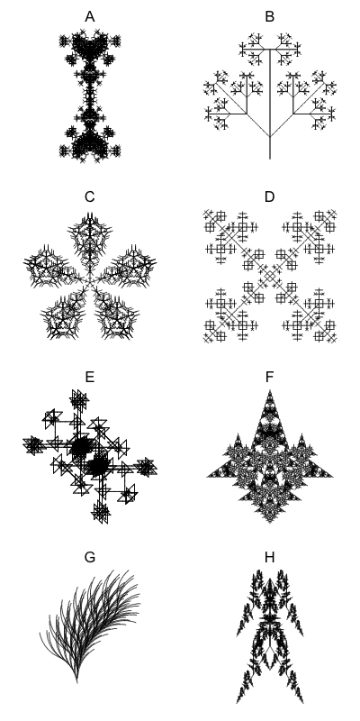

   1. A
   2. B
   3. C
   4. D
   5. E
   6. F
   7. G
   8. H

#### Question

5. Consider the $L$-system (and angle) defined below:
   - Start: `A`
   - Rules:  
     `A > B-ABA-B`  
     `B > A+B+A`
   - Number of recursions (number of iterations):
     - 6
   - Angle
     - 108°

   When we use the resulting string (and angle) to drive turtle graphics, using https://draemm.li/various/fractals/l-systems/, what image is produced?

   You can also use [this L-system string generator](https://chadworley.github.io/Lsys_string_gen.html) along with [Turbo Turtle](https://scratch.mit.edu/projects/1225522722/editor/) to generate the pattern.

   (You will need to adjust other parameters to get image rotated, centered, and scaled.)

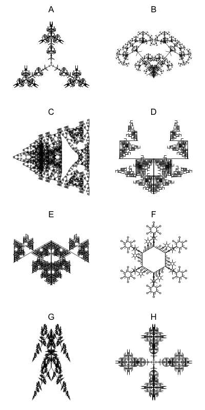

   1. A
   2. B
   3. C
   4. D
   5. E
   6. F
   7. G
   8. H

#### Question

6. Consider the $L$-system (and angle) defined below:
   - Start: `A`
   - Rules:  
     `A > A[+A][-A]B`  
     `B > [--B][++B]A`
   - Number of recursions (number of iterations):
     - 5
   - Angle
     - 30°

   When we use the resulting string (and angle) to drive turtle graphics, using https://draemm.li/various/fractals/l-systems/, what image is produced?

   You can also use [this L-system string generator](https://chadworley.github.io/Lsys_string_gen.html) along with [Turbo Turtle](https://scratch.mit.edu/projects/1225522722/editor/) to generate the pattern.

   (You will need to adjust other parameters to get image rotated, centered, and scaled.)

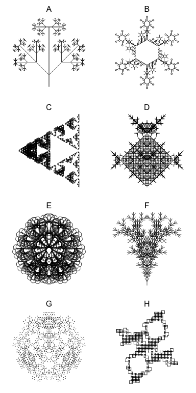

   1. A
   2. B
   3. C
   4. D
   5. E
   6. F
   7. G
   8. H

#### Question

7. Consider the $L$-system (and angle) defined below:
   - Start: `A`
   - Rules:  
     `A > B-ABA-B`  
     `B > A+B+A`
   - Number of recursions (number of iterations):
     - 6
   - Angle
     - 108°

   When we use the resulting string (and angle) to drive turtle graphics, using https://draemm.li/various/fractals/l-systems/, what image is produced?

   You can also use [this L-system string generator](https://chadworley.github.io/Lsys_string_gen.html) along with [Turbo Turtle](https://scratch.mit.edu/projects/1225522722/editor/) to generate the pattern.

   (You will need to adjust other parameters to get image rotated, centered, and scaled.)

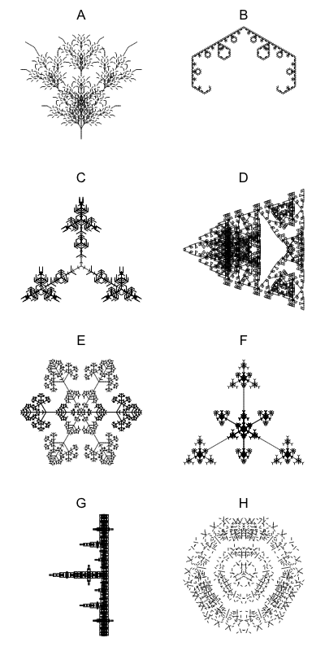

   1. A
   2. B
   3. C
   4. D
   5. E
   6. F
   7. G
   8. H

#### Question

8. Consider the $L$-system (and angle) defined below:
   - Start: `A`
   - Rules:  
     `A > A[+A][-A]B`  
     `B > A[--B][++B]B`
   - Number of recursions (number of iterations):
     - 6
   - Angle
     - 108°

   When we use the resulting string (and angle) to drive turtle graphics, using https://draemm.li/various/fractals/l-systems/, what image is produced?

   You can also use [this L-system string generator](https://chadworley.github.io/Lsys_string_gen.html) along with [Turbo Turtle](https://scratch.mit.edu/projects/1225522722/editor/) to generate the pattern.

   (You will need to adjust other parameters to get image rotated, centered, and scaled.)

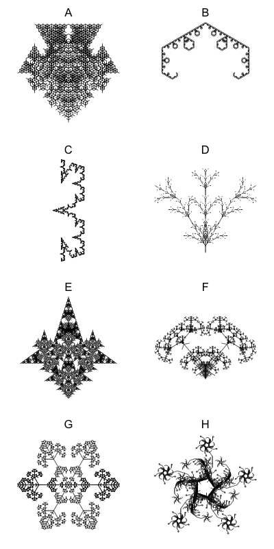

   1. A
   2. B
   3. C
   4. D
   5. E
   6. F
   7. G
   8. H

#### Question

9. Consider the $L$-system (and angle) defined below:
   - Start: `A`
   - Rules:  
     `A > A[+A][-A]A[+B][-B]`  
     `B > A[----B][++++B]B`
   - Number of recursions (number of iterations):
     - 5
   - Angle
     - 45°

   When we use the resulting string (and angle) to drive turtle graphics, using https://draemm.li/various/fractals/l-systems/, what image is produced?

   You can also use [this L-system string generator](https://chadworley.github.io/Lsys_string_gen.html) along with [Turbo Turtle](https://scratch.mit.edu/projects/1225522722/editor/) to generate the pattern.

   (You will need to adjust other parameters to get image rotated, centered, and scaled.)

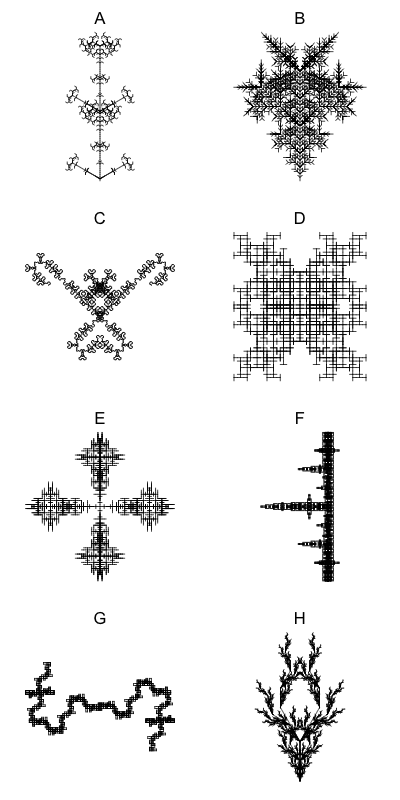

   1. A
   2. B
   3. C
   4. D
   5. E
   6. F
   7. G
   8. H

#### Question

10. Consider the $L$-system (and angle) defined below:
    - Start: `A`
    - Rules:  
      `A > XX[BBB+BB+B]A`  
      `X > XX`  
      `B > B[-XA][+XA]B`
    - Number of recursions (number of iterations):
      - 4
    - Angle
      - 30°

    When we use the resulting string (and angle) to drive turtle graphics, using https://draemm.li/various/fractals/l-systems/, what image is produced?

    You can also use [this L-system string generator](https://chadworley.github.io/Lsys_string_gen.html) along with [Turbo Turtle](https://scratch.mit.edu/projects/1225522722/editor/) to generate the pattern.

    (You will need to adjust other parameters to get image rotated, centered, and scaled.)

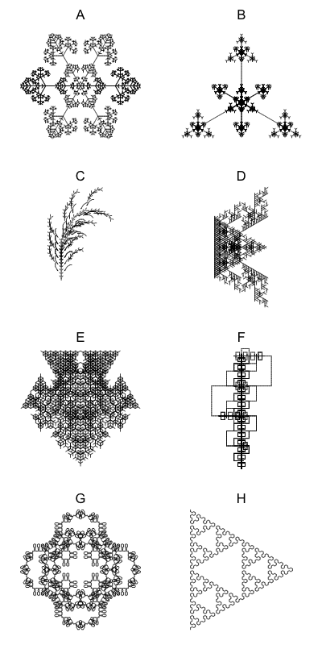

    1. A
    2. B
    3. C
    4. D
    5. E
    6. F
    7. G
    8. H